# Statistical Sampling Methods

Optimization and Simulation of Random Variables with R

Bryan Paget

> “Facts are stubborn things, but statistics are pliable.”

# Statistical Sampling

Statistical sampling methods are techniques used to collect and analyze a representative subset of data from a larger population. These methods are used to make inferences about the characteristics of the larger population based on the properties of the sample.

There are several different types of statistical sampling methods, including random sampling, stratified sampling, cluster sampling, and systematic sampling. The choice of sampling method depends on the research question being studied and the characteristics of the population.

Random sampling is a method in which each member of the population has an equal probability of being selected for the sample. This ensures that the sample is representative of the population and allows for valid inferences to be made about the population based on the sample.

Stratified sampling is a method in which the population is divided into strata, or homogeneous subgroups, and a random sample is taken from each stratum. This ensures that the sample is representative of the different subgroups in the population.

Cluster sampling is a method in which the population is divided into clusters, and a random sample of clusters is selected. All members of the selected clusters are included in the sample. This is useful when it is difficult or expensive to obtain a complete list of the population.

Systematic sampling is a method in which the members of the population are selected based on a regular interval, such as every 10th member. This is useful when the population is ordered in some way, such as in a list or a database.

In summary, statistical sampling methods are techniques used to collect and analyze a representative subset of data from a larger population. These methods are used to make inferences about the characteristics of the population based on the properties of the sample, and the choice of sampling method depends on the research question and the characteristics of the population.

## Optimization and Simulation of Random Variables

Classical methods for simulating random variables from distributions include the inversion method and the acceptance-rejection method. The inversion method involves generating a uniform random variable and then using its inverse cumulative distribution function (CDF) to transform it into a random variable with the desired distribution. The acceptance-rejection method involves generating a random variable from a known distribution and then using a rejection criterion to accept or reject it based on whether or not it has the desired distribution.

In summary, the rejection sampling algorithm involves generating random variables from a known distribution and accepting them with a certain probability based on their similarity to the desired distribution. This can be a useful technique when the desired distribution is difficult to simulate directly, but can be approximated by a known distribution.

## Sampling from Beta($\alpha, \beta$)

The Beta($\alpha, \beta$) distribution is defined as follows:

$$f(x;\alpha,\beta) =
\frac{1}{B(\alpha,\beta)}x^{\alpha - 1}(1 - x)^{\beta - 1}$$

where $B(\alpha,\beta)$ is the beta function and $x \in [0,1]$. The beta function is defined as

$$B(\alpha,\beta) = \int_0^1 x^{\alpha -
1}(1 - x)^{\beta - 1} dx$$

The beta function is a normalizing constant that ensures that the total area under the curve of the Beta($\alpha, \beta$) distribution is equal to 1.

The shape of the Beta($\alpha, \beta$) distribution is determined by the values of $\alpha$ and $\beta$. Increasing $\alpha$ and $\beta$ both shift the distribution to the right and make it more peaked, while decreasing them both has the opposite effect. Increasing $\alpha$ while decreasing $\beta$ (or vice versa) has a more complex effect on the shape of the distribution.

The mean and variance of the Beta($\alpha, \beta$) distribution are given by

$$\mu = \frac{\alpha}{\alpha +
\beta}$$

$$\sigma^2 = \frac{\alpha \beta}{(\alpha +
\beta)^2(\alpha + \beta + 1)}$$

In summary, the Beta($\alpha, \beta$) distribution is a continuous probability distribution that models random variables with values falling inside a finite interval. The shape of the distribution is determined by the values of $\alpha$ and $\beta$, with larger values resulting in a more peaked distribution. The mean and variance of the Beta($\alpha, \beta$) distribution can be calculated using the formulas provided above.

To obtain a Beta($\alpha, \beta$) random variable using the Uniform(0,1) distribution, we can use the following transformation:

$$X = \frac{1}{1 +
(\frac{1}{Y})^{\frac{\alpha}{\beta}}}$$

where $Y \sim \text{Uniform}(0,1)$ and $X \sim \text{Beta}(\alpha, \beta)$.

This transformation uses the inverse cumulative distribution function (CDF) of the Beta($\alpha, \beta$) distribution to transform a random variable from the Uniform(0,1) distribution into a random variable from the Beta($\alpha, \beta$) distribution. The inverse CDF for the Beta($\alpha, \beta$) distribution is given by

$$F^{-1}(x; \alpha, \beta) = \left(
\frac{\beta}{\alpha} (1 - x)
\right)^{-\frac{\alpha}{\beta}}$$

Substituting this into the transformation equation above yields

$$X = \frac{1}{1 + \left(
\frac{\beta}{\alpha} (1 - Y)
\right)^{-\frac{\alpha}{\beta}}}$$

which is the desired transformation for obtaining a Beta($\alpha, \beta$) random variable using the Uniform(0,1) distribution.

In summary, to obtain a Beta($\alpha, \beta$) random variable using the Uniform(0,1) distribution, we can use the transformation given above. This involves using the inverse CDF of the Beta($\alpha, \beta$) distribution to transform a random variable from the Uniform(0,1) distribution into a random variable from the Beta($\alpha, \beta$) distribution.

We want to sample from Beta($\alpha, \beta$) but let’s say we only know how to draw random variables from Uniform(0,1). We can perform the following transformation to obtain a Gamma($n, \lambda$) random variable,

```r
sample.from.gamma <- function(n, lambda) {
  #' Sample from Gamma(n, lambda) distribution.
  #'
  #' @description Sample from the Gamma distribution.
  #' @param n numerical.
  #' @param lambda numerical.
  #' @return
  #' @examples
  u <- runif(min = 0, max = 1, n)
  exp <- -1 / lambda * log(u)
  return(sum(exp))
}
```

which we can then transform into a Beta($a, b$) random variable using the transformation below.

```r
beta.1 <- function(a, b, lambda) {
  #' Sample from Beta(a, b, lambda) distribution.
  #'
  #' @description Sample from the Beta distribution.
  #' @param a numerical.
  #' @param b numerical.
  #' @return
  #' @examples
  #' # Add some code illustrating how to use the function
  x <- sample.from.gamma(a, lambda)
  y <- sample.from.gamma(b, lambda)
  return(x / (x + y))
}
```

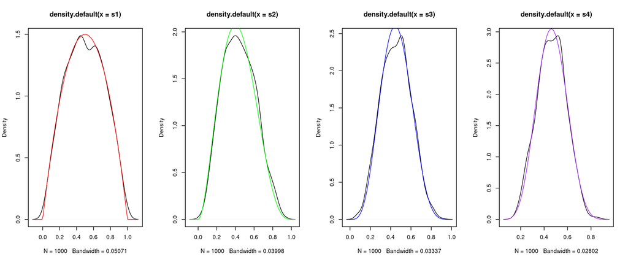

## Sampling from F($m,n$)

The F distribution is a continuous probability distribution that is commonly used in hypothesis testing and analysis of variance. It is defined by two parameters, $d_1$ and $d_2$, which are known as the degrees of freedom. The F distribution has a probability density function given by

$$f(x; d_1, d_2) = \frac{\Gamma(\frac{d_1
+
d_2}{2})}{\Gamma(\frac{d_1}{2})\Gamma(\frac{d_2}{2})}\frac{d_1^{\frac{d_1}{2}}
x^{\frac{d_1}{2} - 1}}{d_2^{\frac{d_2}{2}}(1 + \frac{d_1
x}{d_2})^{\frac{d_1 + d_2}{2}}}$$

where $\Gamma(x)$ is the gamma function.

If $X \sim \text{Beta}(\frac{d_1}{2}, \frac{d_2}{2})$, then the transformation ${d_2 X \over d_1(1-X)}$ has the following probability density function:

$$f(x; d_1, d_2) =
\frac{d_1^{\frac{d_1}{2}} x^{\frac{d_1}{2} - 1}}{d_2^{\frac{d_2}{2}}(1 +
\frac{d_1 x}{d_2})^{\frac{d_1 + d_2}{2}}}$$

Comparing this to the probability density function of the F distribution, we can see that ${d_2 X \over d_1(1-X)} \sim F(d_1, d_2)$. In other words, if $X \sim \text{Beta}(\frac{d_1}{2}, \frac{d_2}{2})$, then the transformation ${d_2 X \over d_1(1-X)}$ yields a random variable with an F distribution with parameters $d_1$ and $d_2$.

In summary, if $X \sim \text{Beta}(\frac{d_1}{2}, \frac{d_2}{2})$, then the transformation ${d_2 X \over d_1(1-X)}$ has an F distribution with parameters $d_1$ and $d_2$. This relationship between the Beta and F distributions is useful in statistical analysis and hypothesis testing.

If $X \sim Beta({d_1 \over 2}, {d_2 \over 2})$, then ${d_2 X \over d_1(1-X)} \sim F(d_1, d_2)$ where $d_1$ and $d_2$ are the degrees of freedom parameters for the **F** distribution.

```r
sample.from.F <- function(X, d1, d2) {
  #' Sample from Gamma(n, lambda) distribution.
  #'
  #' @description: Sample from the Gamma distribution.
  #' @param n numerical.
  #' @param lambda numerical.
  #' @return
  #' @examples
  return(d2 * X / (d1 * (1 - X)))
}
```

And like before, we can draw some samples and plot them.

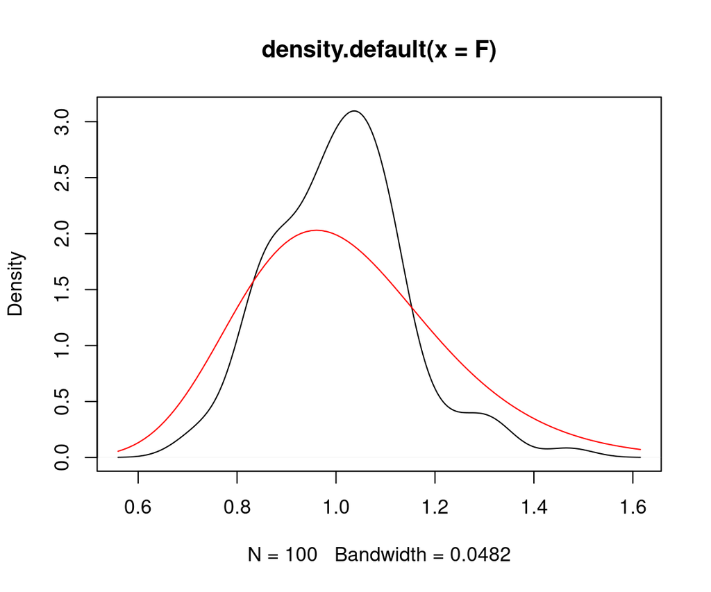

## Sampling from Gaussian N(0,1)

### Box-Muller Transformations

The Box-Muller transformation is a method for generating samples from a Gaussian (normal) distribution using samples from a uniform distribution. It is defined as follows:

$$X = \sqrt{-2 \ln(U_1)} \cos(2 \pi
U_2)$$

$$Y = \sqrt{-2 \ln(U_1)} \sin(2 \pi
U_2)$$

where $U_1$ and $U_2$ are independent samples from a uniform distribution on the interval [0,1]. The variables $X$ and $Y$ are then independent samples from a standard normal distribution with mean 0 and variance 1.

To generate samples from a Gaussian distribution with mean $\mu$ and variance $\sigma^2$, we can use the following transformation:

$$X = \mu + \sigma \sqrt{-2 \ln(U_1)}
\cos(2 \pi U_2)$$

$$Y = \mu + \sigma \sqrt{-2 \ln(U_1)}
\sin(2 \pi U_2)$$

where $U_1$ and $U_2$ are independent samples from a uniform distribution on the interval [0,1]. The variables $X$ and $Y$ are then independent samples from a Gaussian distribution with mean $\mu$ and variance $\sigma^2$.

In summary, the Box-Muller transformation is a method for generating samples from a Gaussian distribution using samples from a uniform distribution. It involves applying a transformation to the uniform samples to obtain samples from the Gaussian distribution. This transformation can be modified to generate samples from a Gaussian distribution with a specified mean and variance.

```r
bmT.1 <- function(n, mu, s) {
  #' Sample from Gamma(n, lambda) distribution.
  #'
  #' @description: Sample from the Gamma distribution.
  #' @param n numerical.
  #' @param lambda numerical.
  #' @return
  #' @examples
  U1 <- runif(n)
  U2 <- runif(n)
  return(s * sqrt(-2 * log(U1)) * cos(2 * pi * U2) + mu)
}

bmT.2 <- function(n, mu, s) {
  #' Sample from Gamma(n, lambda) distribution.
  #'
  #' @description: Sample from the Gamma distribution.
  #' @param n numerical.
  #' @param lambda numerical.
  #' @return
  #' @examples
  U1 <- runif(n)
  U2 <- runif(n)
  return(s * sqrt(-2 * log(U1)) * sin(2 * pi * U2) + mu)
}
```

We can plot these transformations,

They look normal!

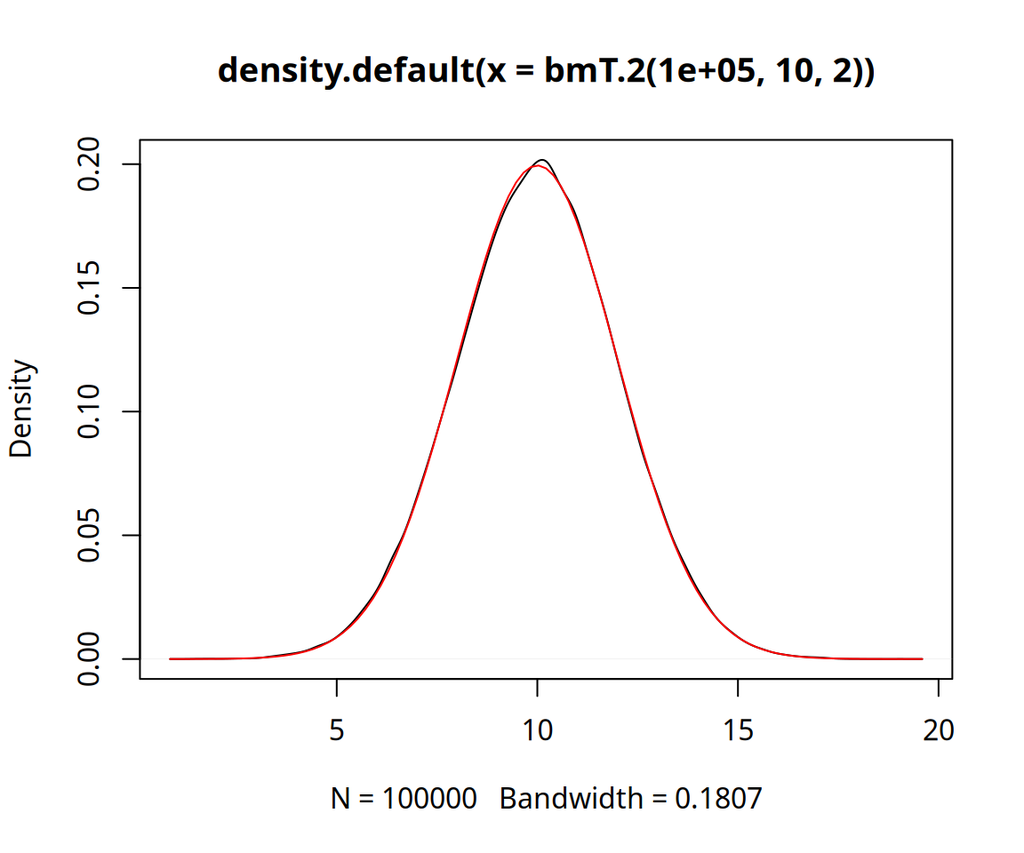

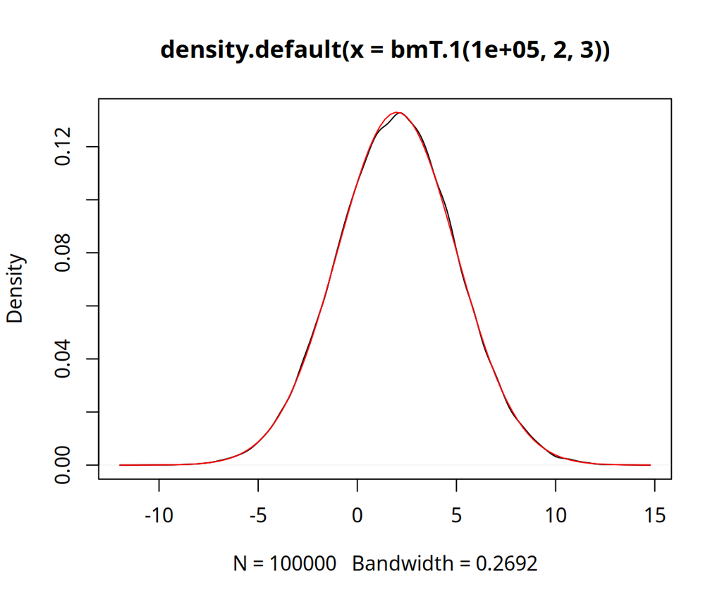

### Accept-Reject Algorithm

We are going to use an accept-reject method to sample from $\mathcal{N}(0,1)$, using the Laplace distribution as a proposal distribution and envelope. In order to sample from the Laplace distribution we will use the following facts, given $U \sim Uniform(-1,2,1/2]$ then $X = \mu - b \cdot \text{sgn}(U) \ln (1 - 2 \cdot |U|)$ has a Laplace distribution with parameters $\mu$ and $b$. We then write the following function to sample from the Laplace distribution.

$$X = \mu - b \cdot \text{sgn}(U) \ln (1 -
2 \cdot |U|)$$

where $U \sim \text{Uniform}(-1,2,1/2]$. The resulting variable $X$ will have a Laplace distribution with parameters $\mu$ and $b$.

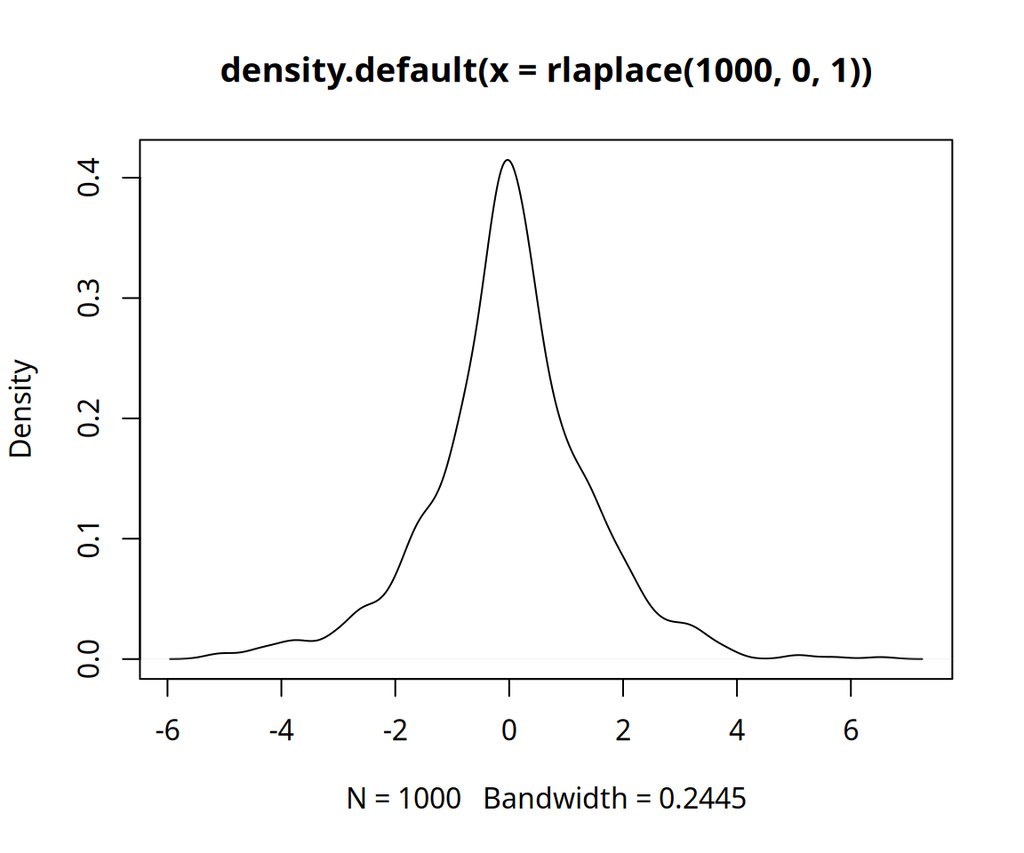

```r
rlaplace<- function(n, mu, b) {
  #' Sample from Gamma(n, lambda) distribution.
  #'
  #' @description: Sample from the Gamma distribution.
  #' @param n numerical.
  #' @param lambda numerical.
  #' @return
  #' @examples
  U <- runif(n, min = -0.5, max = 0.5)
  return(mu - b * sign(U) * log(1 - 2 * abs(U)))
}

plot(density(rlaplace(1000, 0, 1)))
```

And we will need the Laplace density.

```r
laplace.1 <- function(x, mu, b) {
  #' Sample from Gamma(n, lambda) distribution.
  #'
  #' @description: Sample from the Gamma distribution.
  #' @param n numerical.
  #' @param lambda numerical.
  #' @return
  #' @examples
  return(1 / (2 * b) * exp(-1 / b * abs(x - mu)))
}
```

The following function performs the accept-reject algorithm.

```r
gauss.1 <- function(n, mu, sigma) {
  #' Sample from Gamma(n, lambda) distribution.
  #'
  #' @description: Sample from the Gamma distribution.
  #' @param n numerical.
  #' @param lambda numerical.
  #' @return
  #' @examples

  sample <- vector(length = n)

  c <- sqrt(2 * exp(1) / pi)

  for (i in 1:n) {

    accept = FALSE

    while (accept != TRUE) {

      u <- runif(1)
      x <- rlaplace(1, 0, 1)
      U <- dnorm(x, 0, 1)
      L <- laplace.1(x, 0, 1)

      if (u <= (U / (c * L))) {
        accept = TRUE
        sample[i] <- x
      }
    }
  }
  return(sigma * sample + mu)
}
```

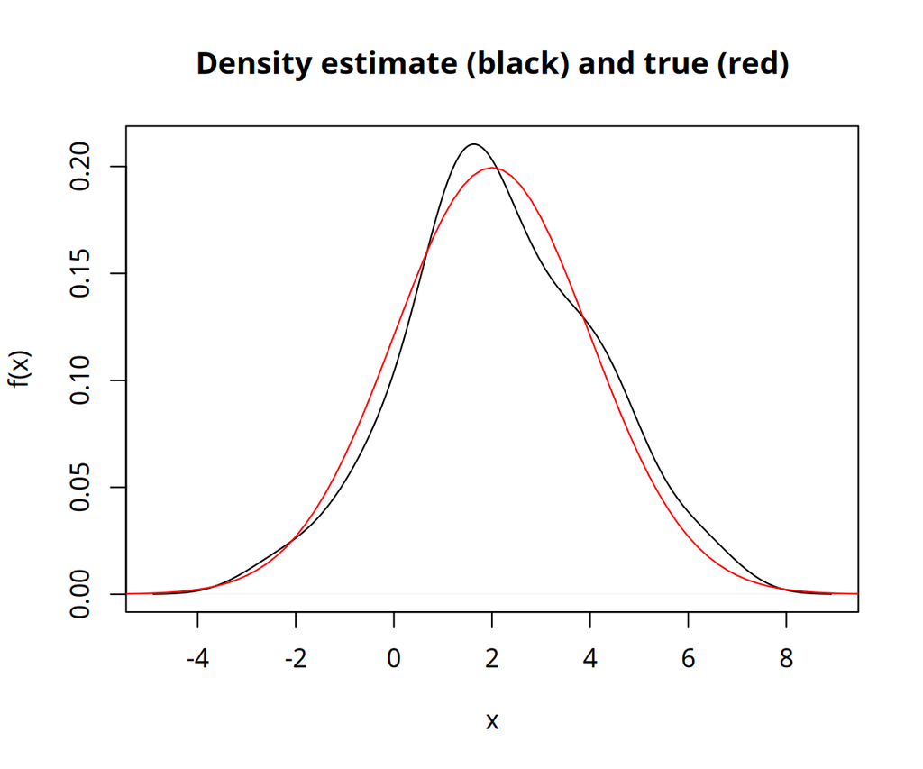

Here we run the algorithm and plot the results.

The results of the microbenchmark comparison show that the Box-Muller method is significantly faster than the accept-reject method for sampling from the Gaussian distribution. This is because the Box-Muller method is a more efficient and direct way of generating samples from the Gaussian distribution, whereas the accept-reject method involves generating samples from two different distributions and then accepting or rejecting them based on a certain criterion.

In general, the Box-Muller method is a more efficient and effective way of generating samples from the Gaussian distribution, and it should be used in preference to the accept-reject method when possible. This is especially true for large-scale applications where computational efficiency is important.

In summary, the results of the microbenchmark comparison show that the Box-Muller method is significantly faster than the accept-reject method for sampling from the Gaussian distribution. The Box-Muller method should be used in preference to the accept-reject method when possible.

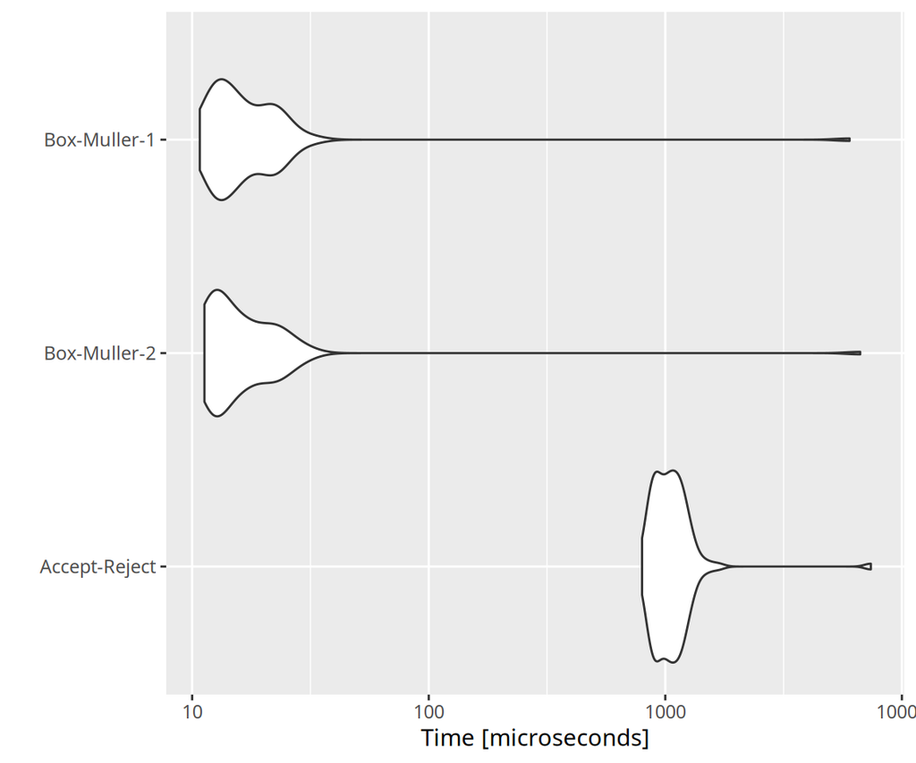

## Expectation Maximization

The EM algorithm is a method for estimating the parameters of a statistical model, typically in the context of missing data or hidden variables. It involves iteratively updating the estimates of the model parameters by using the expectation of the log-likelihood with respect to the current estimates, and then maximizing the expected log-likelihood to obtain new estimates.

And the following is my function,

```r
my.em <- function(col1, col2) {

  mean1 <- 0
  mean2 <- 0
  sigma11 <- 0
  sigma22 <- 0
  sigma12 <- 0
  max.iterations <- 100
  epsilon <- 0.000000000001
  n <- length(col1)

  ## Save the indices of the missing data
  index1 <- c()
  index2 <- c()

  ## Expectation:
  ## Impute missing values with column means
  for (i in 1:n) {

    if (is.na(col1[i])) {
      col1[i] <- mean(col1, na.rm = T)
      index1 <- c(index1, i)
    }

    if (is.na(col2[i])){
      col2[i] <- mean(col2, na.rm = T)
      index2 <- c(index2, i)
    }

  }

  i <- 0
  convergence <- FALSE
  while ((i < max.iterations) && (convergence == FALSE)) {

    ## Maximization:
    s1 <- sum(col1)
    s2 <- sum(col2)
    s11 <- sum(col1 * col1)
    s22 <- sum(col2 * col2)
    s12 <- sum(col1 * col2)

    ## Save the old parameters before we update them
    old.parameters <- c(mean1, mean2, sigma11, sigma12, sigma22)

    ## Update the parameters
    mean1 <- s1 / n
    mean2 <- s2 / n
    sigma11 <- s11 / n - mean1 ** 2
    sigma22 <- s22 / n - mean2 ** 2
    sigma12 <- sigma21 <- s12 / n - mean1 * mean2

    ## Expectation:
    ## Prepare the linear regression coefficients for E(Stuff|Other Stuff)
    b11 <- sigma12 / sigma22
    b10 <- mean1 - b11 * mean2
    b21 <- sigma12 / sigma11
    b20 <- mean2 - b21 * mean1

    ## Replace the indexed elements (they were NA at the onset), with linear
    ## predictions, because I am not sure what else to do:

    col1[index1] <- b10 + col2[index1] * b11
    col2[index2] <- b20 + col1[index2] * b21

    ## Package the parameters
    parameters <- c(mean1, mean2, sigma11, sigma12, sigma22)

    ## Check for convergence
    if (abs(parameters[1] - old.parameters[1]) < epsilon){
      convergence <- TRUE
    }

    i <- i + 1
  }

  return(
    list(
      "Mean1" = mean1,
      "Mean2" = mean2,
      "Covariance" = matrix(c(
        sigma11, sigma12,
        sigma12, sigma22), ncol=2, byrow = TRUE),
      "Column1" = col1,
      "Column2" = col2
    )
  )
}
```

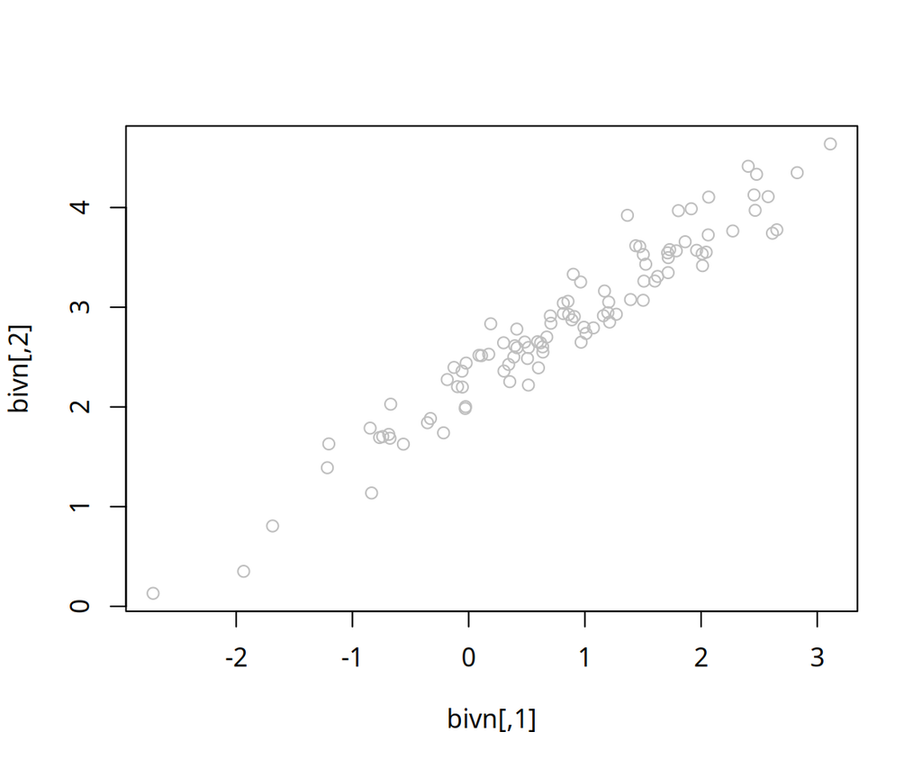

I compared my.em to an R package for data imputation, and from the plot below you can see that my imputations (in red) are close to forming a straight line through the distribution.

The plot you have provided shows that the imputed values generated by your function are close to forming a straight line through the distribution. This is a good sign, as it suggests that your function is generating reasonable estimates for the missing data points.

[output not shown]

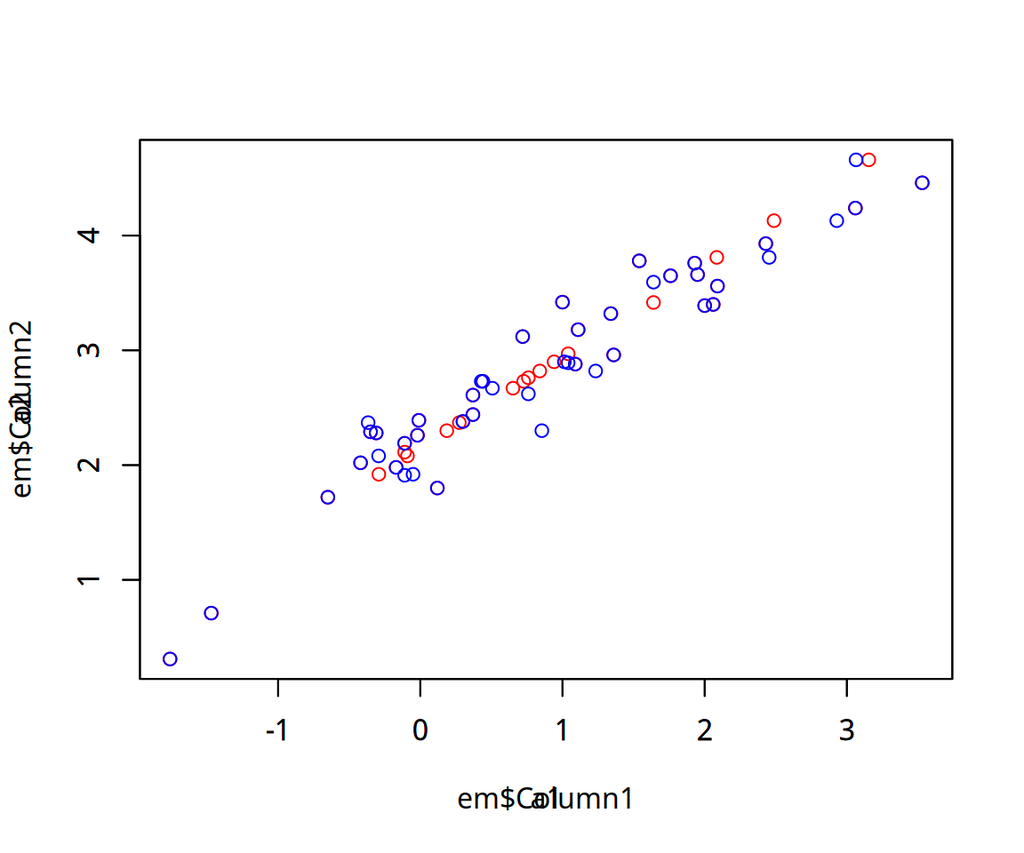

# Example with Data

## Oil Spills

For this section we’ll work with a data set pertaining to oil spills in US waters between 1974 and 1999. Each record includes the year and the following measurements for that year: the number of spills, the amount of imported and exported oil. We expect the amount of oil shipped in a year is related to the number of oil spills. We therefore fit the following model:

$$\begin{align*}
N_{i} \sim Poisson(\lambda_{i} )
\end{align*}$$

where

$$\begin{align*}
\lambda_{i} = \alpha_{1} X_{i,1} + \alpha_{2} X_{i,2}
\end{align*}$$

The Newton-Raphson method is an iterative method for finding the roots of a function. It is often used to find the maximum likelihood estimators (MLEs) of a statistical model, as the MLEs can be found by solving the equations $\frac{\partial \log L}{\partial \alpha_1} = 0$ and $\frac{\partial \log L}{\partial \alpha_2} = 0$, where $\log L$ is the log-likelihood function and $\alpha_1$ and $\alpha_2$ are the model parameters.

First I’ll derive and implement a [Newton-Raphson methon](https://en.wikipedia.org/wiki/Newton's_method) to find maximum likelihood estimators (MLEs) of $\alpha_1$ and $\alpha_2$

A subset of the Oil Spills dataset.

|  | year | N | X1 | X2 |
| --- | --- | --- | --- | --- |
| 21 | 1994 | 0 | 1.290 | 0.65 |
| 22 | 1995 | 1 | 1.235 | 0.59 |
| 23 | 1996 | 0 | 1.340 | 0.56 |
| 24 | 1997 | 0 | 1.440 | 0.51 |
| 25 | 1998 | 0 | 1.450 | 0.42 |
| 26 | 1999 | 0 | 1.510 | 0.44 |

We have some data where we assume $N_1 \sim \text{Poisson}(\lambda_i), \quad \lambda_i = \alpha_1x_{i,1} + \alpha_2x_{i,2}$. We want to find the optimal $\boldsymbol{\alpha} = \left( \alpha_1, \alpha_2 \right)$, and we are going to use the Newton-Raphson method. We do some calculations and the following method appears,

$$\begin{align*}
\boldsymbol{\alpha^{t+1}} = \boldsymbol{\alpha^t} -
\begin{bmatrix}
\sum_{i=1}^n {-k_ix_{i,1}^2 \over (\alpha_1x_{i,1} +
\alpha_2x_{i,2})^2} &
\sum_{i=1}^n {-k_ix_{i,1}x_{i,2} \over (\alpha_1x_{i,1} +
\alpha_2x_{i,2})^2} \\
\sum_{i=1}^n {-k_ix_{i,1}x_{i,2} \over (\alpha_1x_{i,1} +
\alpha_2x_{i,2})^2} &
\sum_{i=1}^n {-k_ix_{i,2}^2 \over (\alpha_1x_{i,1} +
\alpha_2x_{i,2})^2}
\end{bmatrix} ^{-1}
\begin{bmatrix}
\sum_{i=1}^n x_{i,1}\left[ k_i(\alpha_1x_{i,1} +
\alpha_2x_{i,2}^{-1} - 1) \right] \\
\sum_{i=1}^n x_{i,2}\left[ k_i(\alpha_1x_{i,1} +
\alpha_2x_{i,2}^{-1} - 1) \right]
\end{bmatrix}.
\end{align*}$$

And the Fisher scoring version is:

$$\begin{align*}
\boldsymbol{\alpha^{t+1}} = \boldsymbol{\alpha^t} -
\begin{bmatrix}
\sum_{i=1}^n {-x_{i,1}^2 \over (\alpha_1x_{i,1} + \alpha_2x_{i,2})}
&
\sum_{i=1}^n {-x_{i,1}x_{i,2} \over (\alpha_1x_{i,1} +
\alpha_2x_{i,2})} \\
\sum_{i=1}^n {-x_{i,1}x_{i,2} \over (\alpha_1x_{i,1} +
\alpha_2x_{i,2})} &
\sum_{i=1}^n {-x_{i,2}^2 \over (\alpha_1x_{i,1} + \alpha_2x_{i,2})}
\end{bmatrix} ^{-1}
\begin{bmatrix}
\sum_{i=1}^n x_{i,1}\left[ k_i(\alpha_1x_{i,1} +
\alpha_2x_{i,2}^{-1} - 1) \right] \\
\sum_{i=1}^n x_{i,2}\left[ k_i(\alpha_1x_{i,1} +
\alpha_2x_{i,2}^{-1} - 1) \right]
\end{bmatrix}.
\end{align*}$$

The following program computes the mle of the parameters. There is a setting to choose between Fisher scoring and NR.

```r
lprime1 <- function(x1, x2, k, a) {
  #' Fisher Information Matrix.
  #'
  #' @description: Sample from the Gamma distribution.
  #' @param n numerical.
  #' @param lambda numerical.
  #' @return
  #' @examples
  return(rbind(sum(x1 * (k / (a[1] * x1 + a[2] * x2) - 1)),
        sum(x2 * (k / (a[1] * x1 + a[2] * x2) - 1))))
}

lprime2 <- function(x1, x2, k, a) {
  #' Fisher Information Matrix.
  #'
  #' @description: Sample from the Gamma distribution.
  #' @param n numerical.
  #' @param lambda numerical.
  #' @return
  #' @examples
  nw <- sum(-k * x1 ** 2 / (a[1] * x1 + a[2] * x2) ** 2)
  ne <- sum(-k * x1 * x2 / (a[1] * x1 + a[2] * x2) ** 2)
  sw <- sum(-k * x1 * x2 / (a[1] * x1 + a[2] * x2) ** 2)
  se <- sum(-k * x2 ** 2 / (a[1] * x1 + a[2] * x2) ** 2)
  return(matrix(c(nw, ne, sw, se), byrow = T, ncol = 2))
}

F.M <- function(x1, x2, a) {
  #' Fisher Information Matrix.
  #'
  #' @description: Sample from the Gamma distribution.
  #' @param n numerical.
  #' @param lambda numerical.
  #' @return
  #' @examples
  nw <- sum(-x1 ** 2 / (a[1] * x1 + a[2] * x2))
  ne <- sum(-x1 * x2 / (a[1] * x1 + a[2] * x2))
  sw <- sum(-x1 * x2 / (a[1] * x1 + a[2] * x2))
  se <- sum(-x2 ** 2 / (a[1] * x1 + a[2] * x2))
  return(matrix(c(nw, ne, sw, se), byrow = T, ncol = 2))
}

newton.raphson <- function(x1, x2, k, a, e = 10 ^ (-6),
                           maxit = 1000, fisher = FALSE) {
  #' Newton Raphson Method.
  #'
  #' @description: Sample from the Gamma distribution.
  #' @param n numerical.
  #' @param lambda numerical.
  #' @return
  #' @examples

  i <- 1
  convergence <- F
  new.a <- c(0, 0)

  while ((i < maxit) && (convergence == F)) {

    if (fisher == TRUE) {

      .m <- solve(F.M(x1, x2, a)) %*% lprime1(x1, x2, k, a)

    } else {

      .m <- solve(
        lprime2(x1, x2, k, a)) %*% lprime1(x1, x2, k, a)

    }

    new.a <- a - .m

    if (abs(new.a[1] - a[1]) < e) {

      convergence <- T

    } else {

      a <- new.a
      i <- i + 1

    }

  }

  cat(i, "iterations until convergence.")

  return(a)
}
```

I call the function below. I set the initial alpha parameters to something random. I can do this with the Fisher scoring method,

```r
alpha0 <- rnorm(2, 1, 20)

newton.raphson(x1 = oil.spills[, 3],
              x2 = oil.spills[, 4],
              k = oil.spills[, 2],
              a = alpha0,
              e = 0.00001,
              maxit = 100,
              fisher = TRUE
)
```

```
## 13 iterations until convergence.
```

```
##           [,1]
## [1,] 1.0971584
## [2,] 0.9375457
```

but for the NR method, I have to be careful about my initial choice.

```r
alpha0 <- c(1, 1)

newton.raphson(x1 = oil.spills[, 3],
               x2 = oil.spills[, 4],
               k = oil.spills[, 2],
               a = alpha0,
               e = 0.00001,
               maxit = 100,
               fisher = FALSE
)
```

```
## 4 iterations until convergence.
```

```
##           [,1]
## [1,] 1.0971525
## [2,] 0.9375546
```

In addition, the Newton-Raphson method is sensitive to the initial values of the model parameters, and can converge to different values depending on the starting values. This can make it difficult to determine the true MLEs of the model. In contrast, the Fisher scoring method is more stable and does not depend as much on the initial values of the model parameters.

# Conclusion

This conversation discusses classical methods for simulating random variables from probability distributions, and specifically focuses on the rejection sampling algorithm. Rejection sampling is a method for generating samples from a target distribution by using a proposal distribution and an envelope function. It involves generating samples from the proposal distribution and then accepting them with a certain probability based on how similar they are to the target distribution.

The conversation also discusses the use of the Newton-Raphson and Fisher scoring methods for finding the maximum likelihood estimators (MLEs) of a statistical model. Both methods involve iteratively updating the estimates of the model parameters using the gradient of the log-likelihood function, but the Fisher scoring method is generally considered to be more robust and stable than the Newton-Raphson method.

In summary, this conversation covers the rejection sampling algorithm and the use of the Newton-Raphson and Fisher scoring methods for finding the MLEs of a statistical model. These methods are commonly used in statistical analysis to estimate the parameters of a model and make predictions based on the data.

# Citations

1. https://statisticsbyjim.com/probability/beta-distribution/